# Hierarchical_modeling

louis

17 septembre 2017

## Lesson 11: Hierarchical modeling

### Lesson 11.2

#### Data

Let’s fit our hierarhical model for counts of chocolate chips. The data can be found in cookies.dat.

```r
dat = read.table(file="cookies.dat", header=TRUE)
head(dat)
```

```
##   chips location
## 1    12        1
## 2    12        1
## 3     6        1
## 4    13        1
## 5    12        1
## 6    12        1
```

```r
table(dat$location)
```

```
##
##  1  2  3  4  5
## 30 30 30 30 30
```

We can also visualize the distribution of chips by location.

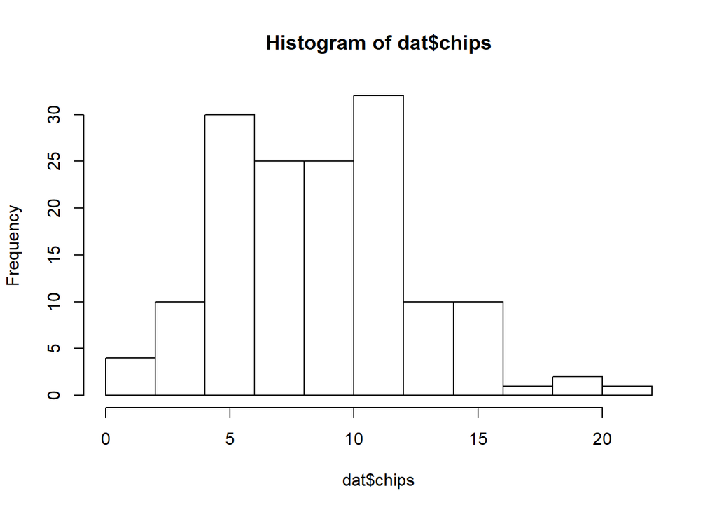

```r
hist(dat$chips)
```

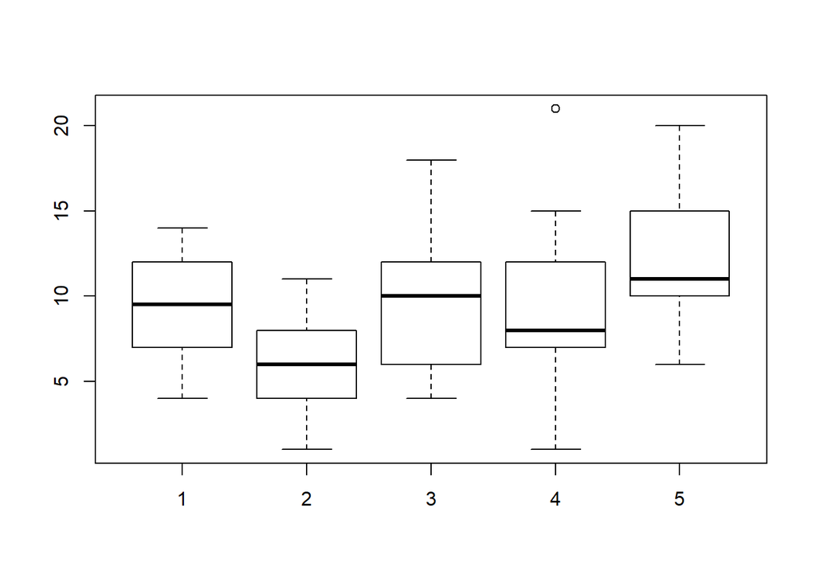

```r
boxplot(chips ~ location, data=dat)
```

### Prior predictive checks

Before implementing the model, we need to select prior distributions for $\alpha$ and $\beta$, the hyperparameters governing the gamma distribution for the $\lambda$ arameters. First, think about what the $\lambda$’s represent. For location , $\lambda_j$ is the expected number of chocolate chips per cookie. Hence, $\alpha$ and $\beta$ control the distribution of these means between locations. The mean of this gamma distribution will represent the overall mean of number of chips for all cookies. The variance of this gamma distribution controls the variability between locations. If this is high, the mean number of chips will vary widely from location to location. If it is small, the mean number of chips will be nearly the same from location to location.

To see the effects of different priors on the distribution of $\lambda$’s, we can simulate. Suppose we try independent exponential priors for $\alpha$ and $\beta$.

```r
set.seed(112)
n_sim = 500
alpha_pri = rexp(n_sim, rate=1.0/2.0)
beta_pri = rexp(n_sim, rate=5.0)
mu_pri = alpha_pri/beta_pri
sig_pri = sqrt(alpha_pri/beta_pri^2)

summary(mu_pri)
```

```
##     Min.  1st Qu.   Median     Mean  3rd Qu.     Max.
##    0.021    2.983    9.852   61.127   29.980 4858.786
```

```r
summary(sig_pri)
```

```
##      Min.   1st Qu.    Median      Mean   3rd Qu.      Max.
##    0.1834    3.3663    8.5488   41.8137   22.2219 2865.6461
```

After simulating from the priors for $\alpha$ and $\beta$, we can use those samples to simulate further down the hierarchy:

```r
lam_pri = rgamma(n=n_sim, shape=alpha_pri, rate=beta_pri)
summary(lam_pri)
```

```
##      Min.   1st Qu.    Median      Mean   3rd Qu.      Max.
##     0.000     1.171     7.667    83.062    28.621 11005.331
```

Or for a prior predictive reconstruction of the original data set:

```r
(lam_pri = rgamma(n=5, shape=alpha_pri[1:5], rate=beta_pri[1:5]))
```

```
## [1] 66.444084  9.946688  6.028319 15.922568 47.978587
```

```r
(y_pri = rpois(n=150, lambda=rep(lam_pri, each=30)))
```

```
##   [1] 63 58 64 63 70 62 61 48 71 73 70 77 66 60 72 77 69 62 66 71 49 80 66
##  [24] 75 74 55 62 90 65 57 12  9  7 10 12 10 11  7 14 13  9  6  6 13  7 10
##  [47] 12  9  9 10  7  8  6  9  7 10 13 13  8 12  6 10  3  6  7  4  6  7  5
##  [70]  5  4  3  6  2  8  4  8  4  5  7  1  4  5  3  8  8  3  1  7  3 16 14
##  [93] 13 17 17 12 13 13 16 16 15 14 11 10 13 17 16 19 16 17 15 16  7 17 21
## [116] 16 12 15 14 13 52 44 51 46 39 40 40 44 46 59 45 49 58 42 31 52 43 47
## [139] 53 41 48 57 35 60 51 58 36 34 41 59
```

Because these priors have high variance and are somewhat noninformative, they produce unrealistic predictive distributions. Still, enough data would overwhelm the prior, resulting in useful posterior distributions. Alternatively, we could tweak and simulate from these prior distributions until they adequately represent our prior beliefs. Yet another approach would be to re-parameterize the gamma prior, which we’ll demonstrate as we fit the model.

### Lesson 11.3

#### JAGS Model

```r
library("rjags")
mod_string = " model {
for (i in 1:length(chips)) {
  chips[i] ~ dpois(lam[location[i]])
}

for (j in 1:max(location)) {
  lam[j] ~ dgamma(alpha, beta)
}

alpha = mu^2 / sig^2
beta = mu / sig^2

mu ~ dgamma(2.0, 1.0/5.0)
sig ~ dexp(1.0)

} "

set.seed(113)

data_jags = as.list(dat)

params = c("lam", "mu", "sig")

mod = jags.model(textConnection(mod_string), data=data_jags, n.chains=3)
```

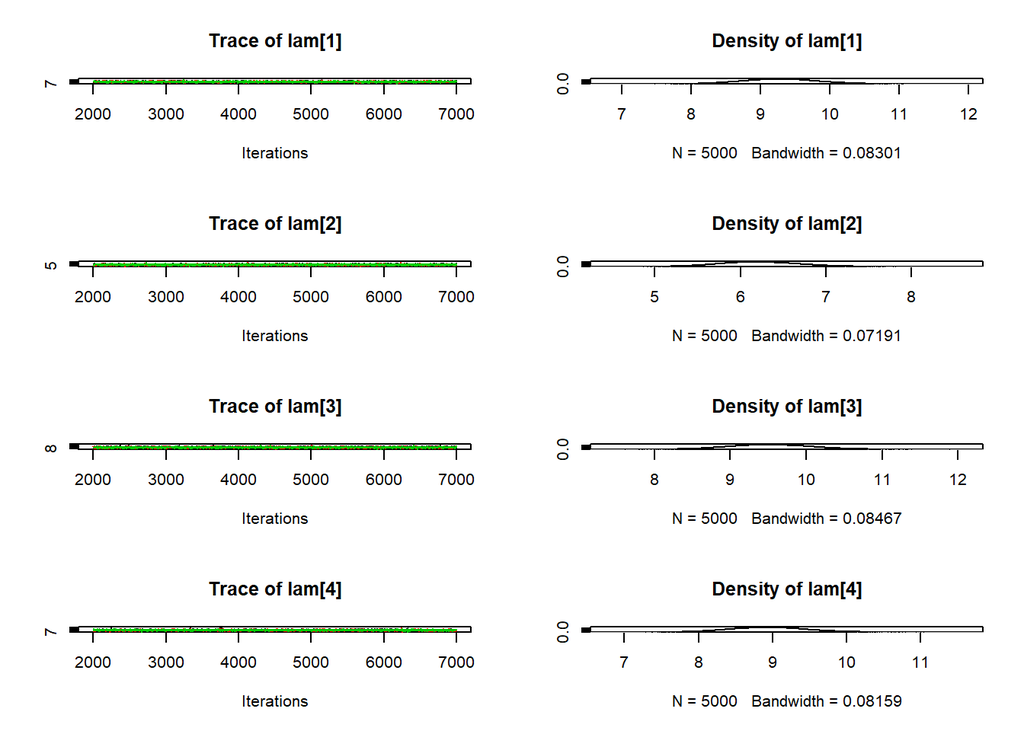

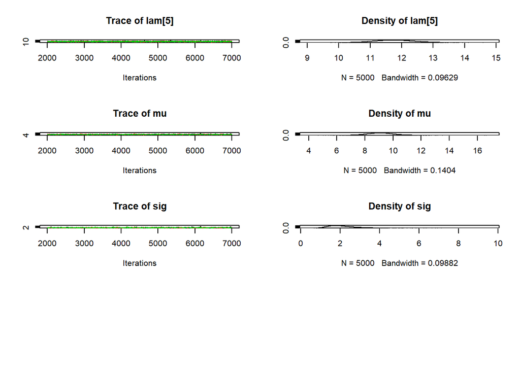

```r
update(mod, 1e3)

mod_sim = coda.samples(model=mod,
                       variable.names=params,
                       n.iter=5e3)
mod_csim = as.mcmc(do.call(rbind, mod_sim))

## convergence diagnostics
plot(mod_sim)
```

```r
gelman.diag(mod_sim)
```

```
## Potential scale reduction factors:
##
##        Point est. Upper C.I.
## lam[1]          1          1
## lam[2]          1          1
## lam[3]          1          1
## lam[4]          1          1
## lam[5]          1          1
## mu              1          1
## sig             1          1
##
## Multivariate psrf
##
## 1
```

```r
autocorr.diag(mod_sim)
```

```
##               lam[1]       lam[2]       lam[3]       lam[4]        lam[5]
## Lag 0   1.0000000000  1.000000000  1.000000000  1.000000000  1.0000000000
## Lag 1   0.0093427503  0.127971934  0.021538052  0.021353927  0.0664224191
## Lag 5  -0.0058970357  0.015026148 -0.001569915 -0.015773358  0.0094916334
## Lag 10  0.0009320900 -0.007782566 -0.019667877  0.012698608 -0.0001967687
## Lag 50  0.0002586035 -0.008113684  0.003189625 -0.005008286 -0.0050619438
##                  mu          sig
## Lag 0   1.000000000  1.000000000
## Lag 1   0.389823670  0.604915265
## Lag 5   0.026435725  0.107749738
## Lag 10 -0.003988496  0.009579037
## Lag 50 -0.004775320 -0.016670821
```

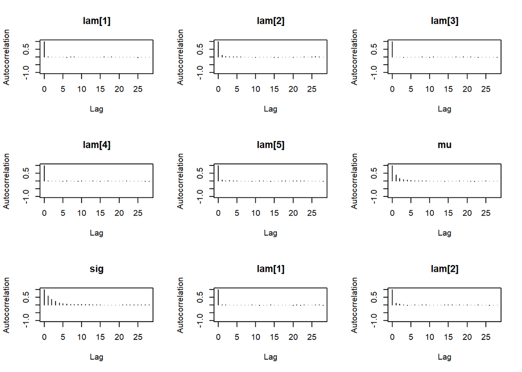

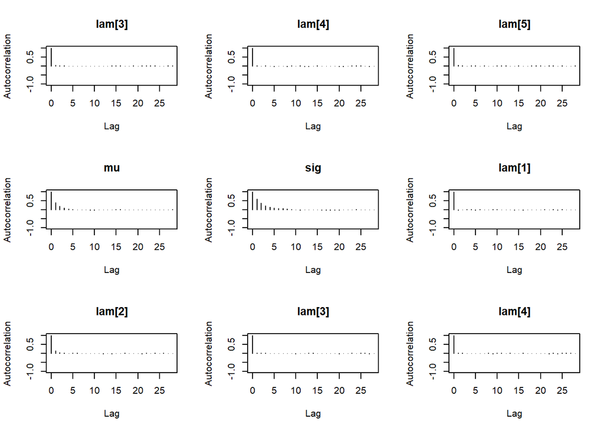

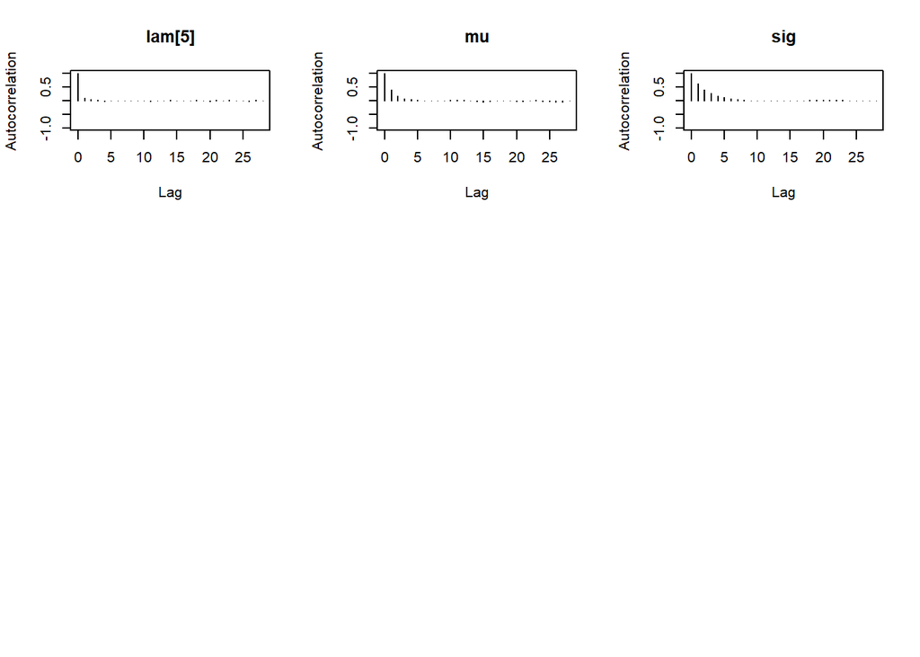

```r
autocorr.plot(mod_sim)
```

```r
effectiveSize(mod_sim)
```

```
##    lam[1]    lam[2]    lam[3]    lam[4]    lam[5]        mu       sig
## 14724.187 10632.604 14551.782 14503.696 12415.427  5981.841  3570.680
```

```r
## compute DIC
dic = dic.samples(mod, n.iter=1e3)
```

### Model Checking

After assessing convergence, we can check the fit via residuals. With a hierarhcical model, there are now two levels of residuals: the observation level and the location mean level. To simplify, we’ll look at the residuals associated with the posterior means of the parameters.

First, we have observation residuals, based on the estimates of location means.

```r
## observation level residuals
(pm_params = colMeans(mod_csim))
```

```
##    lam[1]    lam[2]    lam[3]    lam[4]    lam[5]        mu       sig
##  9.282779  6.223618  9.531263  8.945647 11.767102  9.108554  2.099118
```

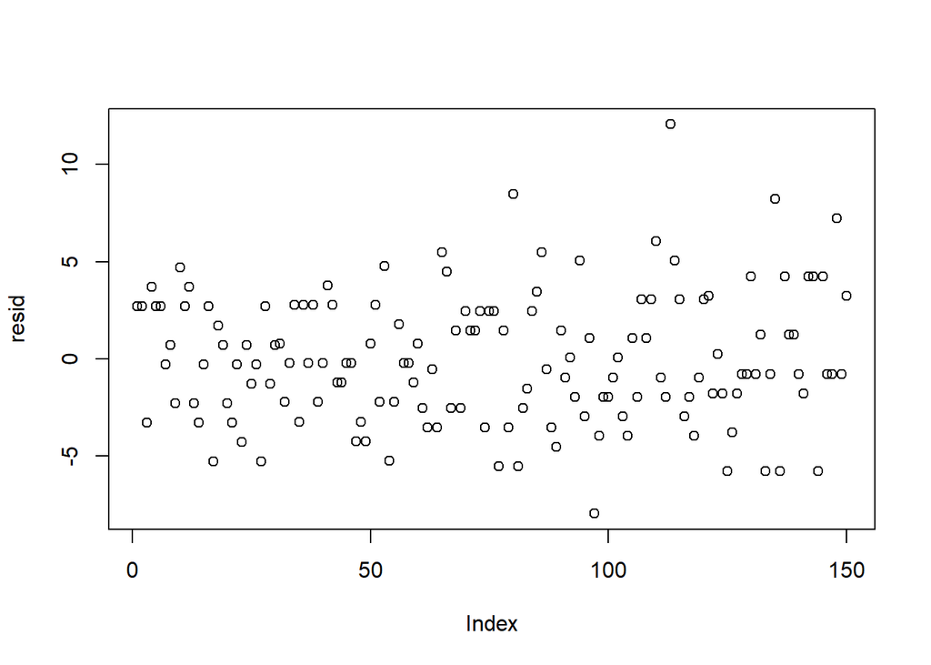

```r
yhat = rep(pm_params[1:5], each=30)
resid = dat$chips - yhat
plot(resid)
```

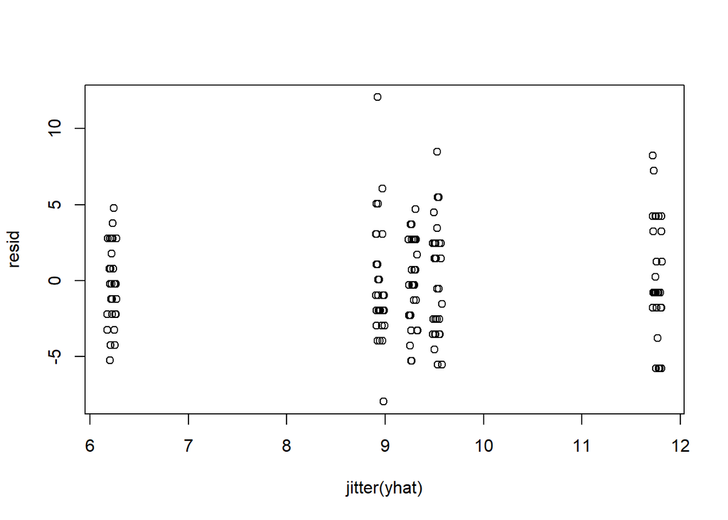

```r
plot(jitter(yhat), resid)
```

```r
var(resid[yhat<7])
```

```
## [1] 6.447126
```

```r
var(resid[yhat>11])
```

```
## [1] 13.72414
```

Also, we can look at how the location means differ from the overall mean $\mu$.

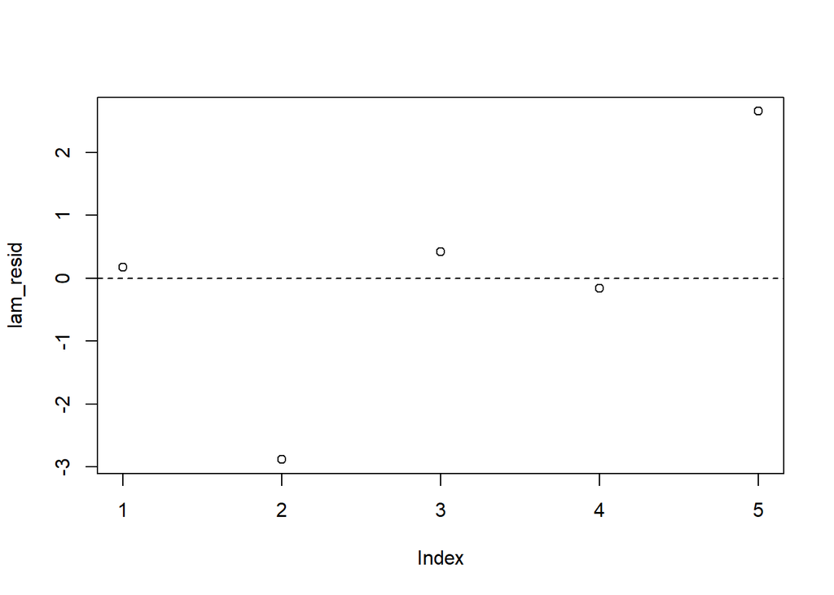

```r
## location level residuals
lam_resid = pm_params[1:5] - pm_params["mu"]
plot(lam_resid)
abline(h=0, lty=2)
```

We don’t see any obvious violations of our model assumptions.

### Results

```r
summary(mod_sim)
```

```
##
## Iterations = 2001:7000
## Thinning interval = 1
## Number of chains = 3
## Sample size per chain = 5000
##
## 1. Empirical mean and standard deviation for each variable,
##    plus standard error of the mean:
##
##          Mean     SD Naive SE Time-series SE
## lam[1]  9.283 0.5358 0.004375       0.004417
## lam[2]  6.224 0.4642 0.003790       0.004504
## lam[3]  9.531 0.5466 0.004463       0.004535
## lam[4]  8.946 0.5274 0.004306       0.004382
## lam[5] 11.767 0.6216 0.005075       0.005591
## mu      9.109 1.0070 0.008222       0.013029
## sig     2.099 0.7332 0.005986       0.012295
##
## 2. Quantiles for each variable:
##
##          2.5%    25%    50%    75%  97.5%
## lam[1]  8.262  8.917  9.280  9.640 10.344
## lam[2]  5.346  5.904  6.211  6.531  7.167
## lam[3]  8.488  9.159  9.521  9.897 10.645
## lam[4]  7.942  8.584  8.935  9.290 10.024
## lam[5] 10.577 11.342 11.750 12.178 13.017
## mu      7.180  8.479  9.086  9.694 11.236
## sig     1.101  1.595  1.956  2.450  3.905
```

#### Lesson 11.4

#### Posterior predictive simulation

Just as we did with the prior distribution, we can use these posterior samples to get Monte Carlo estimates that interest us from the posterior predictive distribution.

For example, we can use draws from the posterior distribution of $\mu$ and $\sigma$ to simulate the posterior predictive distribution of the mean for a new location.

```r
(n_sim = nrow(mod_csim))
```

```
## [1] 15000
```

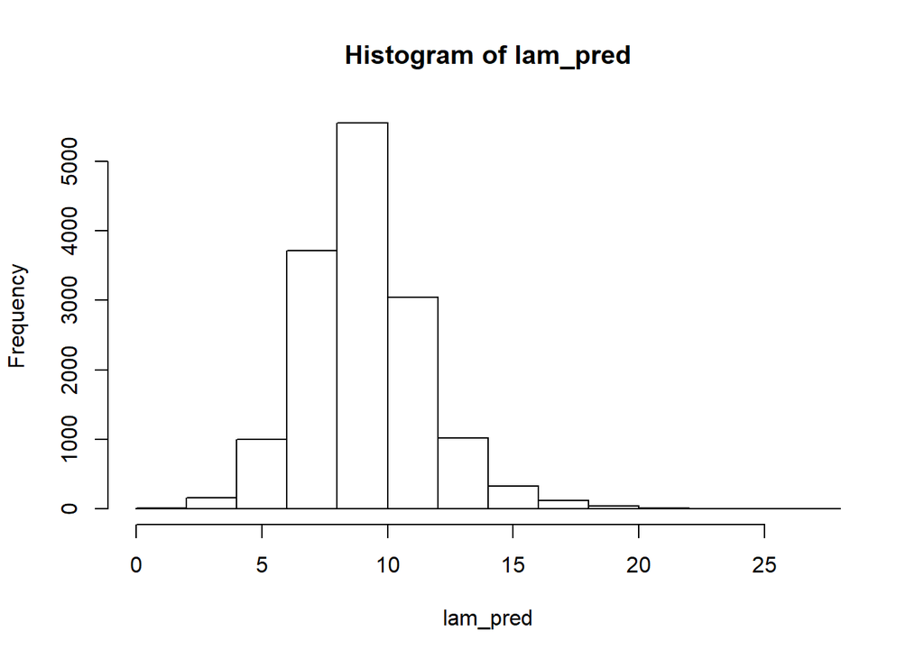

```r
lam_pred = rgamma(n=n_sim, shape=mod_csim[,"mu"]^2/mod_csim[,"sig"]^2,
                  rate=mod_csim[,"mu"]/mod_csim[,"sig"]^2)
hist(lam_pred)
```

```r
mean(lam_pred > 15)
```

```
## [1] 0.02046667
```

Using these $\lambda$ draws, we can go to the observation level and simulate the number of chips per cookie, which takes into account the uncertainty in $\lambda$:

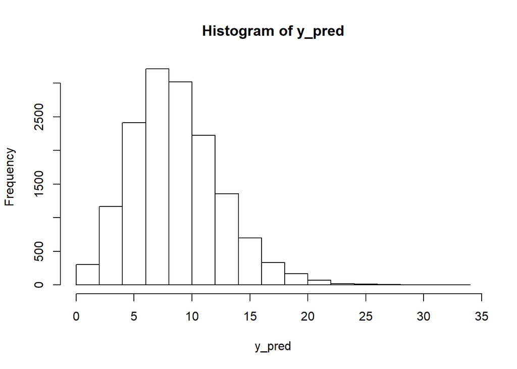

```r
y_pred = rpois(n=n_sim, lambda=lam_pred)
hist(y_pred)
```

```r
mean(y_pred > 15)
```

```
## [1] 0.06033333
```

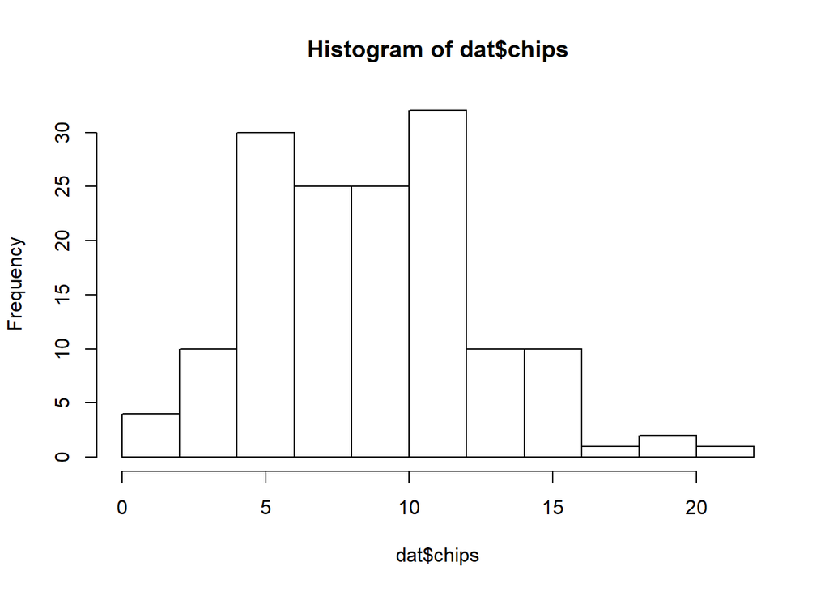

```r
hist(dat$chips)
```

Finally, we could answer questions like: what is the posterior probability that the next cookie produced in Location 1 will have fewer than seven chips?

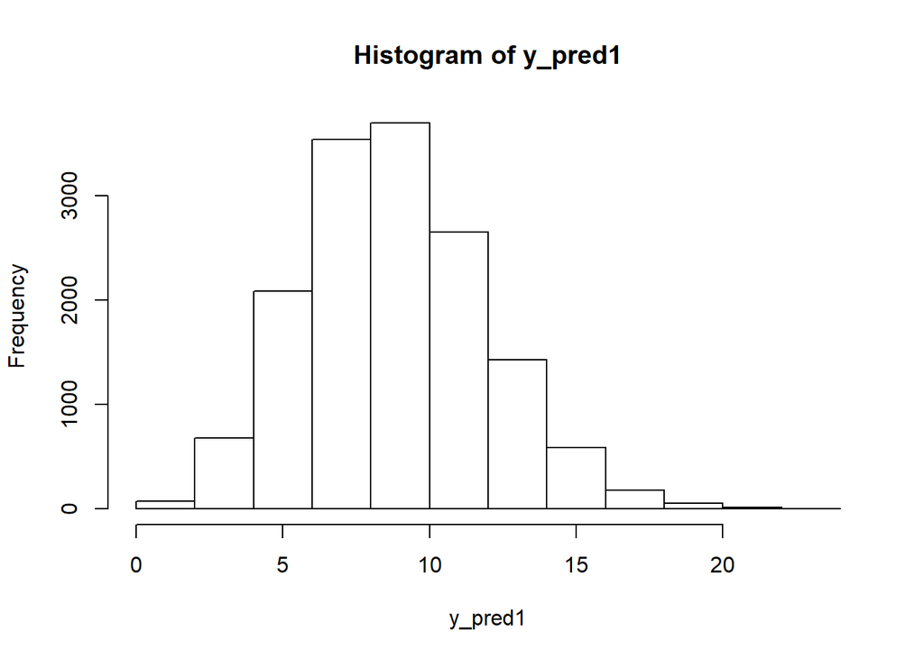

```r
y_pred1 = rpois(n=n_sim, lambda=mod_csim[,"lam[1]"])
hist(y_pred1)
```

```r
mean(y_pred1 < 7)
```

```
## [1] 0.1890667
```

#### Lesson 11.6

#### Random intercept linear model

We can extend the linear model for the Leinhardt data on infant mortality by incorporating the region variable. We’ll do this with a hierarhcical model, where each region has its own intercept.

```r
library("car")
data("Leinhardt")
#?Leinhardt
str(Leinhardt)
```

```
## 'data.frame':    105 obs. of  4 variables:
##  $ income: int  3426 3350 3346 4751 5029 3312 3403 5040 2009 2298 ...
##  $ infant: num  26.7 23.7 17 16.8 13.5 10.1 12.9 20.4 17.8 25.7 ...
##  $ region: Factor w/ 4 levels "Africa","Americas",..: 3 4 4 2 4 4 4 4 4 4 ...
##  $ oil   : Factor w/ 2 levels "no","yes": 1 1 1 1 1 1 1 1 1 1 ...
```

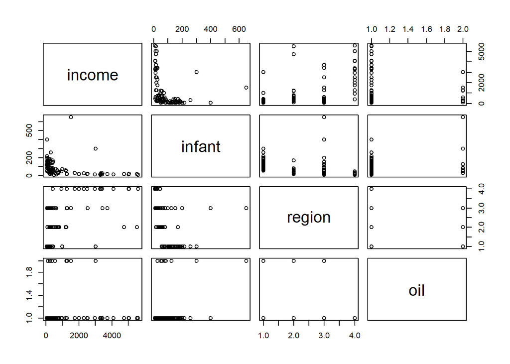

```r
pairs(Leinhardt)
```

```r
head(Leinhardt)
```

```
##           income infant   region oil
## Australia   3426   26.7     Asia  no
## Austria     3350   23.7   Europe  no
## Belgium     3346   17.0   Europe  no
## Canada      4751   16.8 Americas  no
## Denmark     5029   13.5   Europe  no
## Finland     3312   10.1   Europe  no
```

Previously, we worked with infant mortality and income on the logarithmic scale. Recall also that we had to remove some missing data.

```r
dat = na.omit(Leinhardt)
dat$logincome = log(dat$income)
dat$loginfant = log(dat$infant)
str(dat)
```

```
## 'data.frame':    101 obs. of  6 variables:
##  $ income   : int  3426 3350 3346 4751 5029 3312 3403 5040 2009 2298 ...
##  $ infant   : num  26.7 23.7 17 16.8 13.5 10.1 12.9 20.4 17.8 25.7 ...
##  $ region   : Factor w/ 4 levels "Africa","Americas",..: 3 4 4 2 4 4 4 4 4 4 ...
##  $ oil      : Factor w/ 2 levels "no","yes": 1 1 1 1 1 1 1 1 1 1 ...
##  $ logincome: num  8.14 8.12 8.12 8.47 8.52 ...
##  $ loginfant: num  3.28 3.17 2.83 2.82 2.6 ...
##  - attr(*, "na.action")=Class 'omit'  Named int [1:4] 24 83 86 91
##   .. ..- attr(*, "names")= chr [1:4] "Iran" "Haiti" "Laos" "Nepal"
```

Now we can fit the proposed model:

```r
library("rjags")

mod_string = " model {
  for (i in 1:length(y)) {
    y[i] ~ dnorm(mu[i], prec)
    mu[i] = a[region[i]] + b[1]*log_income[i] + b[2]*is_oil[i]
  }

  for (j in 1:max(region)) {
    a[j] ~ dnorm(a0, prec_a)
  }

  a0 ~ dnorm(0.0, 1.0/1.0e6)
  prec_a ~ dgamma(1/2.0, 1*10.0/2.0)
  tau = sqrt( 1.0 / prec_a )

  for (j in 1:2) {
    b[j] ~ dnorm(0.0, 1.0/1.0e6)
  }

  prec ~ dgamma(5/2.0, 5*10.0/2.0)
  sig = sqrt( 1.0 / prec )
} "

set.seed(116)
data_jags = list(y=dat$loginfant, log_income=dat$logincome,
                  is_oil=as.numeric(dat$oil=="yes"), region=as.numeric(dat$region))
data_jags$is_oil
```

```
##   [1] 0 0 0 0 0 0 0 0 0 0 0 0 0 0 0 0 0 0 0 0 1 1 1 1 1 1 1 1 0 0 0 0 0 0 0
##  [36] 0 0 0 0 0 0 0 0 0 0 0 0 0 0 0 0 0 0 0 0 0 0 0 0 0 0 0 0 0 0 0 0 0 0 0
##  [71] 0 0 0 0 0 0 0 0 0 0 0 0 0 0 0 0 0 0 0 0 0 0 0 0 0 0 0 0 0 0 0
```

```r
table(data_jags$is_oil, data_jags$region)
```

```
##
##      1  2  3  4
##   0 31 20 24 18
##   1  3  2  3  0
```

```r
params = c("a0", "a", "b", "sig", "tau")

mod = jags.model(textConnection(mod_string), data=data_jags, n.chains=3)
```

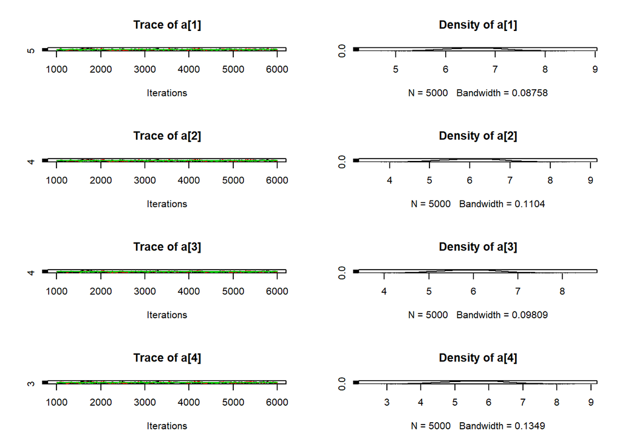

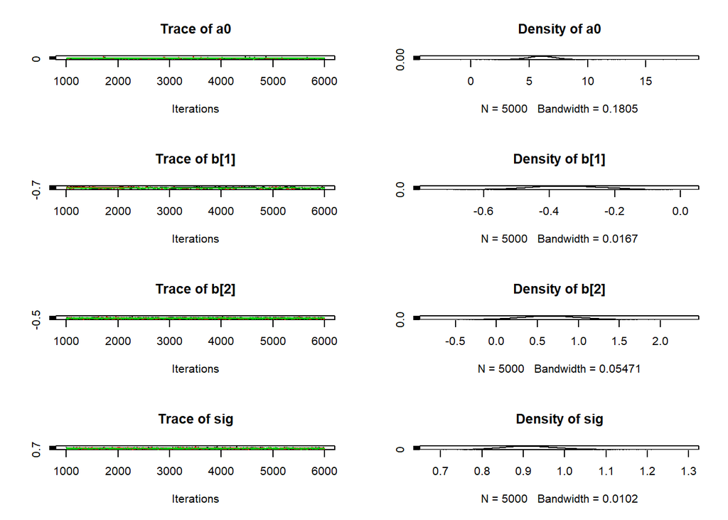

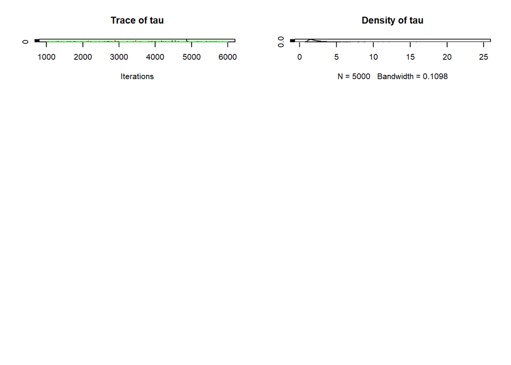

```r
update(mod, 1e3) # burn-in

mod_sim = coda.samples(model=mod,
                       variable.names=params,
                       n.iter=5e3)

mod_csim = as.mcmc(do.call(rbind, mod_sim)) # combine multiple chains

## convergence diagnostics
plot(mod_sim)
```

```r
gelman.diag(mod_sim)
```

```
## Potential scale reduction factors:
##
##      Point est. Upper C.I.
## a[1]       1.02       1.05
## a[2]       1.01       1.05
## a[3]       1.02       1.05
## a[4]       1.02       1.06
## a0         1.00       1.01
## b[1]       1.02       1.06
## b[2]       1.00       1.00
## sig        1.00       1.00
## tau        1.00       1.00
##
## Multivariate psrf
##
## 1.01
```

```r
autocorr.diag(mod_sim)
```

```
##             a[1]      a[2]      a[3]      a[4]         a0      b[1]
## Lag 0  1.0000000 1.0000000 1.0000000 1.0000000 1.00000000 1.0000000
## Lag 1  0.9209774 0.9224557 0.9182005 0.9377992 0.27099566 0.9804395
## Lag 5  0.8488742 0.8558415 0.8480191 0.8687760 0.23629064 0.9069797
## Lag 10 0.7649912 0.7713218 0.7655133 0.7849645 0.22002611 0.8183340
## Lag 50 0.3305692 0.3356079 0.3370375 0.3409895 0.08312881 0.3556164
##              b[2]          sig          tau
## Lag 0  1.00000000  1.000000000  1.000000000
## Lag 1  0.14287453  0.053840758  0.301482482
## Lag 5  0.05289345 -0.000783125  0.007953900
## Lag 10 0.03256453  0.009744356  0.009596957
## Lag 50 0.00244195 -0.004663007 -0.025605135
```

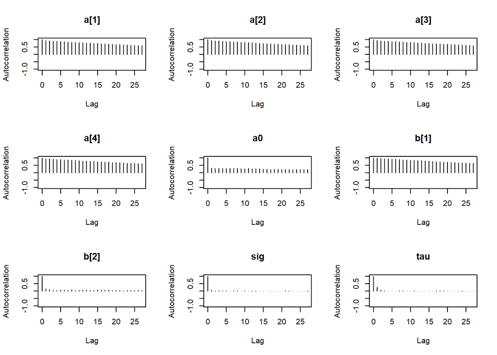

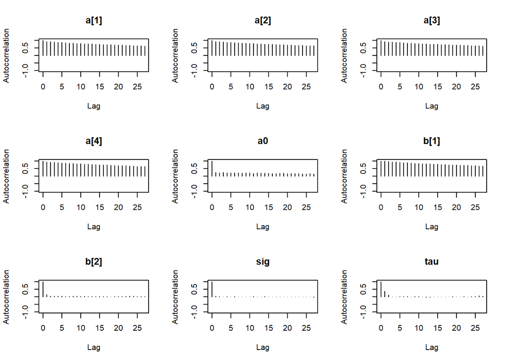

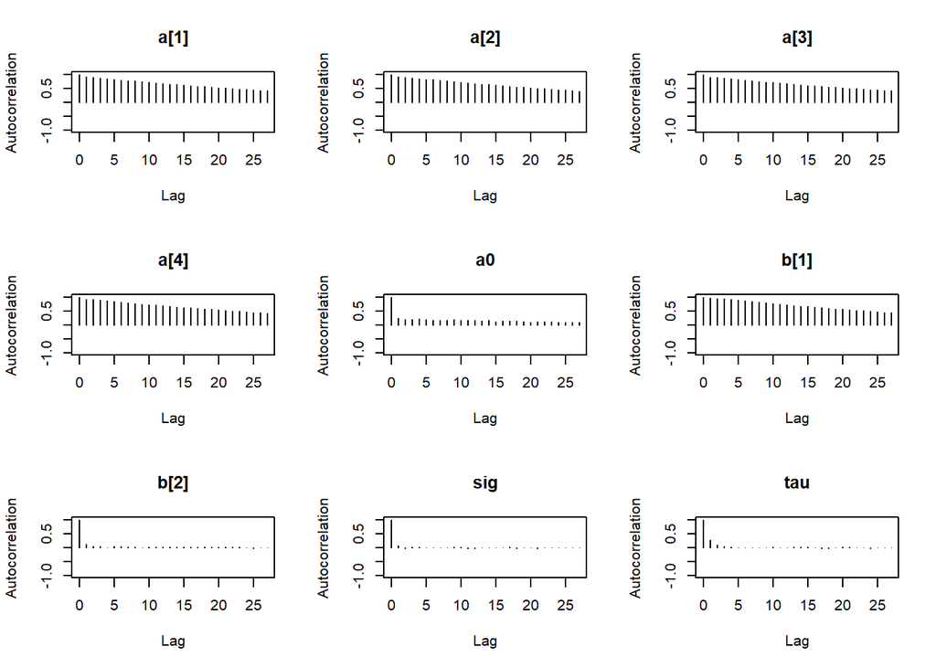

```r
autocorr.plot(mod_sim)
```

```r
effectiveSize(mod_sim)
```

```
##       a[1]       a[2]       a[3]       a[4]         a0       b[1]
##   157.4686   160.1172   163.3923   162.2669   707.1730   155.4136
##       b[2]        sig        tau
##  6262.9326 13413.0560  7971.4967
```

### Results

Convergence looks okay, so let’s compare this with the old model from Lesson 7 using DIC:

```r
dic.samples(mod, n.iter=1e3)
```

```
## Mean deviance:  214.1
## penalty 7.434
## Penalized deviance: 221.6
```

It appears that this model is an improvement over the non-hierarchical one we fit earlier. Notice that the penalty term, which can be interpreted as the “effective” number of parameters, is less than the actual number of parameters (nine). There are fewer “effective” parameters because they are “sharing” information or “borrowing strength” from each other in the hierarhical structure. If we had skipped the hierarchy and fit one intercept, there would have been four parameters. If we had fit separate, independent intercepts for each region, there would have been seven parameters (which is close to what we ended up with).

Finally, let’s look at the posterior summary.

```r
summary(mod_sim)
```

```
##
## Iterations = 1001:6000
## Thinning interval = 1
## Number of chains = 3
## Sample size per chain = 5000
##
## 1. Empirical mean and standard deviation for each variable,
##    plus standard error of the mean:
##
##         Mean      SD  Naive SE Time-series SE
## a[1]  6.5974 0.56535 0.0046160      0.0469083
## a[2]  6.0693 0.71274 0.0058195      0.0588291
## a[3]  5.8984 0.63316 0.0051698      0.0514198
## a[4]  5.6073 0.87071 0.0071093      0.0707018
## a0    6.0397 1.31460 0.0107336      0.0533702
## b[1] -0.3502 0.10781 0.0008802      0.0090546
## b[2]  0.6485 0.35319 0.0028838      0.0049203
## sig   0.9185 0.06652 0.0005432      0.0005744
## tau   2.0428 1.05032 0.0085758      0.0118508
##
## 2. Quantiles for each variable:
##
##         2.5%     25%     50%     75%   97.5%
## a[1]  5.5227  6.2041  6.5984  6.9865  7.7261
## a[2]  4.7091  5.5791  6.0664  6.5575  7.4793
## a[3]  4.6962  5.4627  5.8986  6.3291  7.1567
## a[4]  3.9668  4.9953  5.6139  6.2046  7.3232
## a0    3.4376  5.2668  6.0370  6.8286  8.6002
## b[1] -0.5632 -0.4241 -0.3503 -0.2757 -0.1469
## b[2] -0.0389  0.4083  0.6495  0.8837  1.3402
## sig   0.8005  0.8721  0.9145  0.9603  1.0591
## tau   0.9783  1.4110  1.7824  2.3607  4.5781
```

In this particular model, the intercepts do not have a real interpretation because they correspond to the mean response for a country that does not produce oil and has $0 log-income per capita (which is $1 income per capita). We can interpret a0a0 as the overall mean intercept and $\tau$ as the standard deviation of intercepts across regions.

#### Other models

We have not investigated adding interaction terms, which might be appropriate. We only considered adding hierarchy on the intercepts, but in reality nothing prevents us from doing the same for other terms in the model, such as the coefficients for income and oil. We could try any or all of these alternatives and see how the DIC changes for those models. This, together with other model checking techniques we have discussed could be used to identify your best model that you can use to make inferences and predictions.

### Quizz n°1

```r
dat <- read.csv(file="data1_quizzHierarchical.csv", header=TRUE)
head(dat)
```

```
##      y grp
## 1  1.2   1
## 2  1.4   1
## 3 -0.5   1
## 4  0.3   1
## 5  0.9   1
## 6  2.3   1
```

```r
library("rjags")

mod_string = " model {
for (i in 1:length(y)) {
  industry[i] ~ dnorm(theta[grp[i]], sig)
}

for (j in 1:max(grp)) {
  theta[j] ~ dnorm(mu, tau)
}

mu ~ dnorm(0, 1e6)
tau ~ dgamma(1/2, 3/2)
sig ~ dgamma(1, 1)

} "

set.seed(113)

data_jags = as.list(dat)

params = c("theta", "mu", "sig", "tau")

mod = jags.model(textConnection(mod_string), data=data_jags, n.chains=3)
```

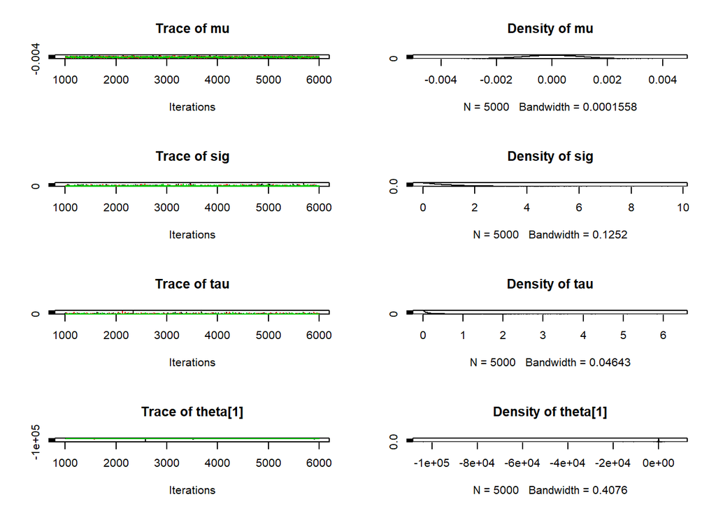

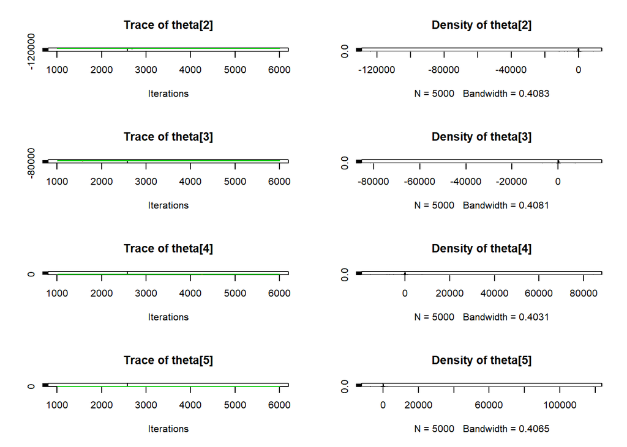

```r
update(mod, 1e3)

mod_sim = coda.samples(model=mod,
                       variable.names=params,
                       n.iter=5e3)
mod_csim = as.mcmc(do.call(rbind, mod_sim))
## convergence diagnostics
plot(mod_sim)
```

```r
gelman.diag(mod_sim)
```

```
## Potential scale reduction factors:
##
##          Point est. Upper C.I.
## mu             1.00       1.00
## sig            1.00       1.00
## tau            1.00       1.00
## theta[1]       1.24       1.25
## theta[2]       1.19       1.19
## theta[3]       1.07       1.07
## theta[4]       1.10       1.10
## theta[5]       1.09       1.09
##
## Multivariate psrf
##
## 1
```

```r
autocorr.diag(mod_sim)
```

```
##                  mu           sig          tau      theta[1]      theta[2]
## Lag 0   1.000000000  1.0000000000 1.0000000000  1.000000e+00  1.0000000000
## Lag 1   0.009698299  0.0111867753 0.0003063374  8.143606e-05  0.0005320308
## Lag 5   0.009474032  0.0005200681 0.0009934143 -2.257637e-04  0.0001696122
## Lag 10  0.001476465 -0.0067268709 0.0016867247  7.198817e-04 -0.0051294295
## Lag 50 -0.005211721 -0.0079660029 0.0088015815 -1.076262e-04  0.0006330086
##             theta[3]      theta[4]      theta[5]
## Lag 0   1.0000000000  1.0000000000  1.000000e+00
## Lag 1  -0.0004105560 -0.0007744485 -4.434025e-05
## Lag 5  -0.0001028230 -0.0005170465 -1.204175e-04
## Lag 10 -0.0001127913 -0.0005616202 -1.587845e-03
## Lag 50 -0.0005683178 -0.0001366169 -2.705348e-04
```

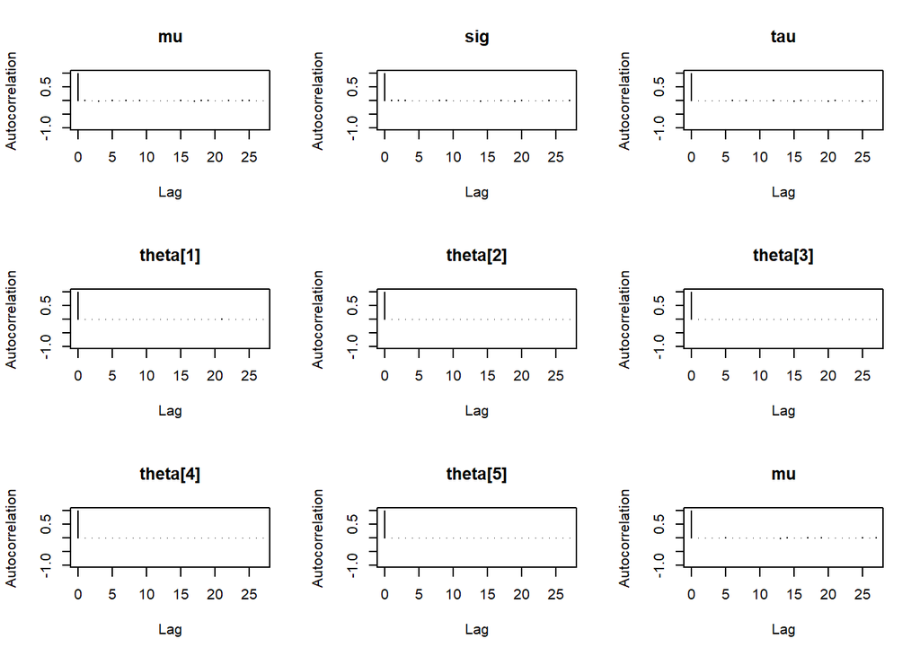

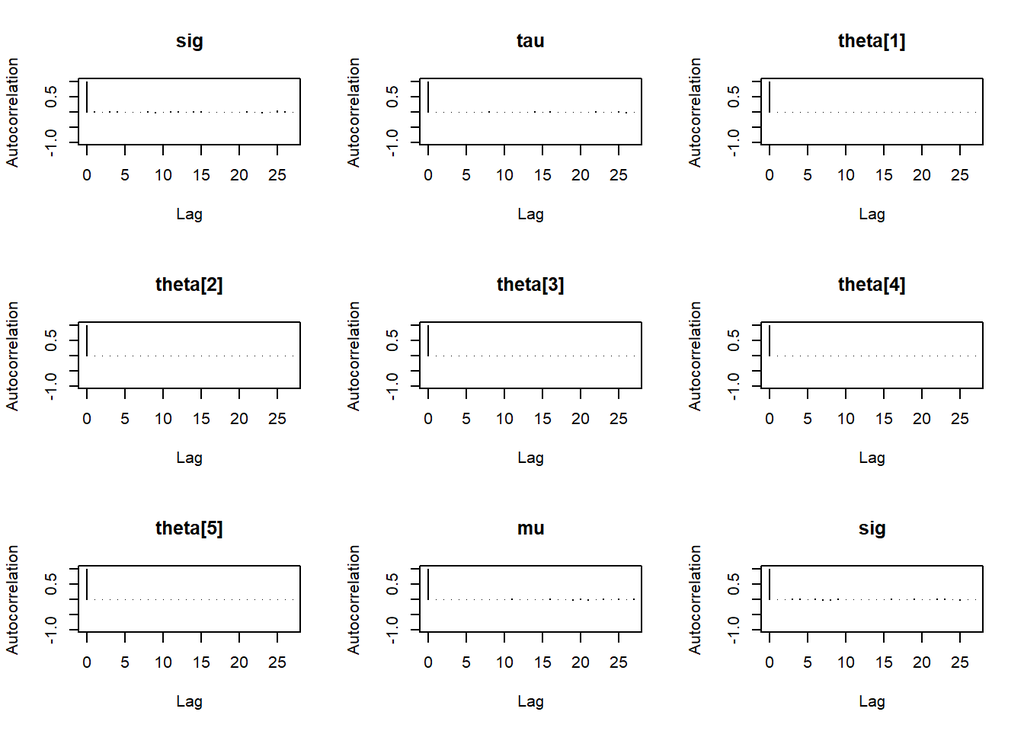

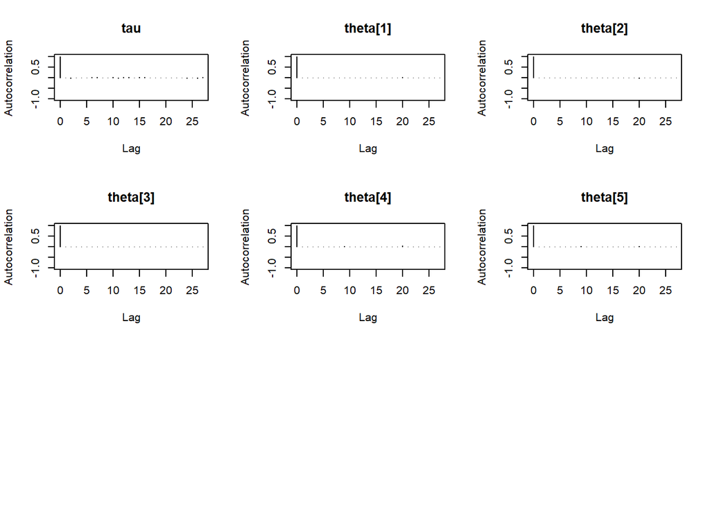

```r
autocorr.plot(mod_sim)
```

```r
effectiveSize(mod_sim)
```

```
##       mu      sig      tau theta[1] theta[2] theta[3] theta[4] theta[5]
## 14795.14 13792.68 15271.84 15000.00 15000.00 15000.00 15000.00 15000.00
```

```r
#
# means_anova <- tapply(dat$y, INDEX=dat$grp, FUN=mean)
#
# plot(means_anova)
# points(theta, col = "red")
```

## Quizz Partie 2:

```r
library("rjags")

library("MASS")
data("OME")

dat = subset(OME, OME != "N/A")
dat$OME = factor(dat$OME) # relabel OME
dat$ID = as.numeric(factor(dat$ID)) # relabel ID so there are no gaps in numbers (they now go from 1 to 63)

## Original reference model and covariate matrix
mod_glm = glm(Correct/Trials ~ Age + OME + Loud + Noise, data=dat, weights=Trials, family="binomial")
X = model.matrix(mod_glm)[,-1]

## Original model (that needs to be extended)
mod_string = " model {
    for (i in 1:length(y)) {
        y[i] ~ dbin(phi[i], n[i])
        logit(phi[i]) = b0 + b[1]*Age[i] + b[2]*OMElow[i] + b[3]*Loud[i] + b[4]*Noiseincoherent[i]
    }

    b0 ~ dnorm(0.0, 1.0/5.0^2)
    for (j in 1:4) {
        b[j] ~ dnorm(0.0, 1.0/4.0^2)
    }

} "

data_jags = as.list(as.data.frame(X))
data_jags$y = dat$Correct
data_jags$n = dat$Trials
data_jags$ID = dat$ID

set.seed(116)
data_jags = list(y=data_jags$y, Age=data_jags$Age, OMElow=data_jags$OMElow, Loud=data_jags$Loud, Noiseincoherent=data_jags$Noiseincoherent, n=data_jags$n)

params = c("b0", "b")

mod = jags.model(textConnection(mod_string), data=data_jags, n.chains=3)
```

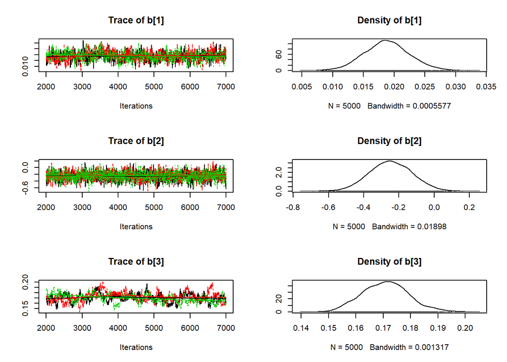

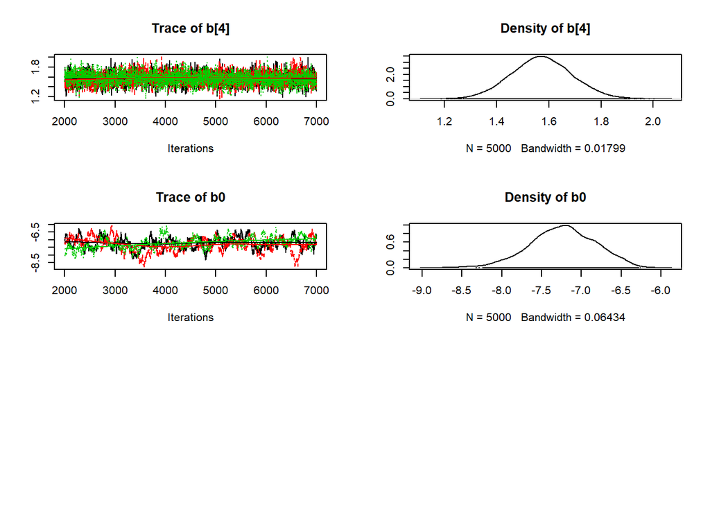

```r
update(mod, 1e3) # burn-in

mod_sim = coda.samples(model=mod,
                       variable.names=params,
                       n.iter=5e3)

mod_csim = as.mcmc(do.call(rbind, mod_sim)) # combine multiple chains

## convergence diagnostics
plot(mod_sim)
```

```r
gelman.diag(mod_sim)
```

```
## Potential scale reduction factors:
##
##      Point est. Upper C.I.
## b[1]       1.02       1.06
## b[2]       1.01       1.02
## b[3]       1.15       1.43
## b[4]       1.00       1.02
## b0         1.17       1.50
##
## Multivariate psrf
##
## 1.12
```

```r
autocorr.diag(mod_sim)
```

```
##              b[1]      b[2]      b[3]       b[4]        b0
## Lag 0  1.00000000 1.0000000 1.0000000 1.00000000 1.0000000
## Lag 1  0.91232382 0.8178120 0.9823832 0.50188493 0.9869406
## Lag 5  0.64079617 0.3767678 0.9186495 0.09061072 0.9356369
## Lag 10 0.43570861 0.1443983 0.8490220 0.06843135 0.8733096
## Lag 50 0.08774393 0.0142715 0.5126122 0.03432724 0.5246507
```

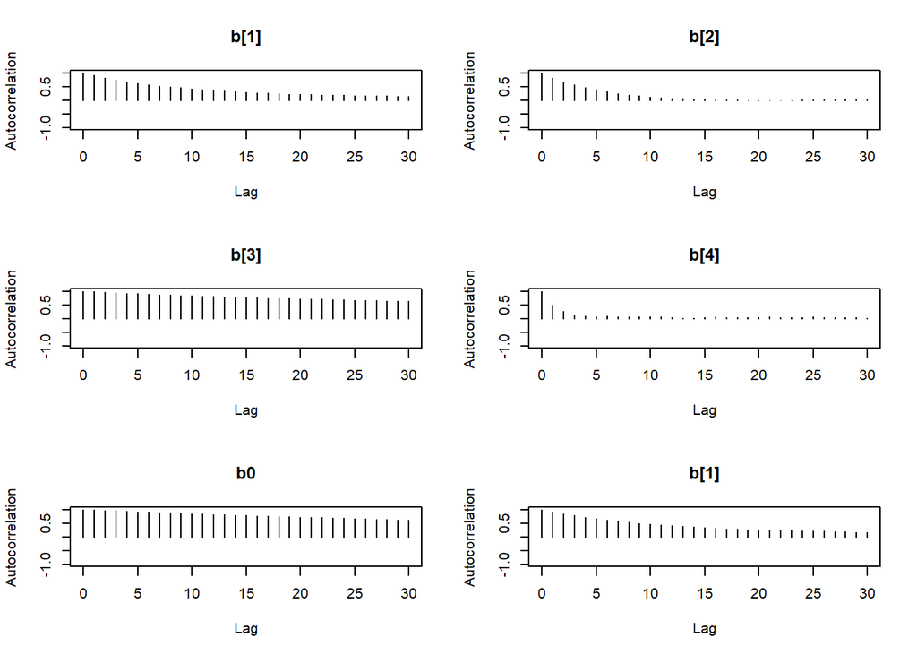

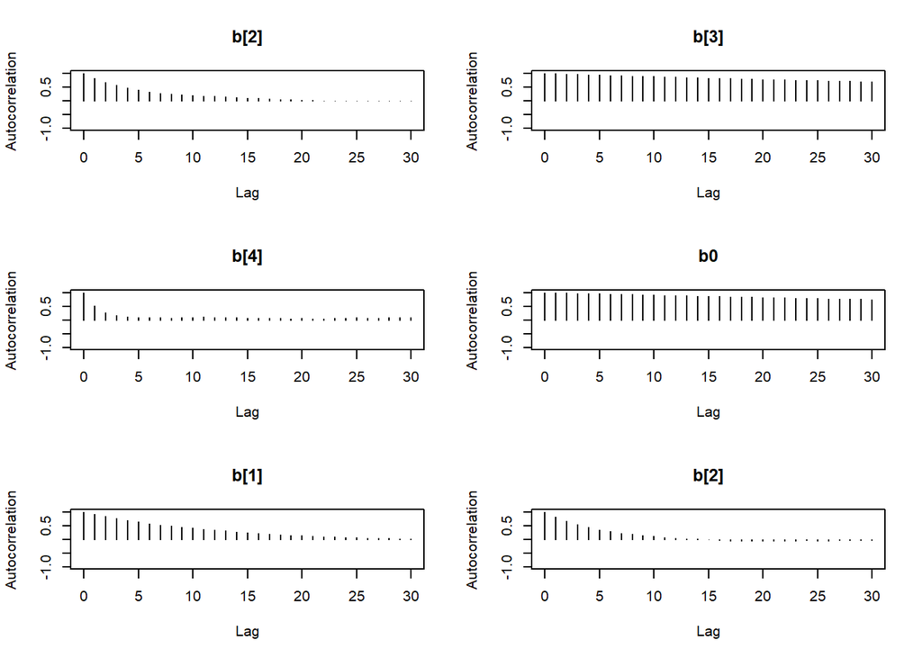

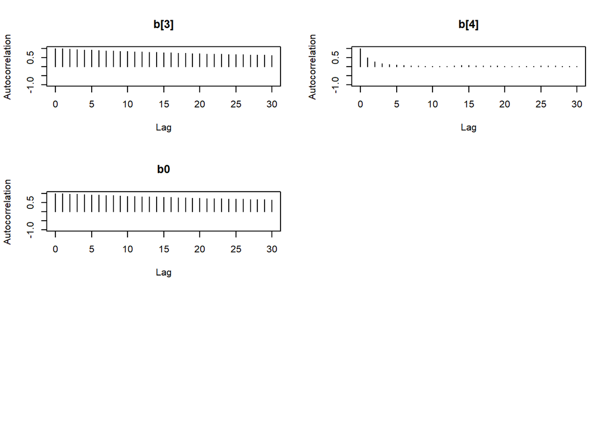

```r
autocorr.plot(mod_sim)
```

```r
effectiveSize(mod_sim)
```

```
##       b[1]       b[2]       b[3]       b[4]         b0
##  635.59547 1463.24692  131.39070 2934.06164   98.59915
```

```r
dic.samples(mod, n.iter=1e3)
```

```
## Mean deviance:  1258
## penalty 5.15
## Penalized deviance: 1263
```

```r
dic.samples(mod, n.iter=1e3)
```

```
## Mean deviance:  1258
## penalty 4.974
## Penalized deviance: 1263
```